# Assignment 5 - Heirarchical Clustering

S.S.Ananth Kumar

10/11/2021

.libPaths(“C:\Users\Ananth\OneDrive\Desktop\MSBA Kent\Fall 2021\Fundamentals of Machine Learning\Assignment\Ass 2”) install.packages(“treemap”)

**Libraries**

```r
library(readr)
library(tidyverse)
library(cluster)
library(caret)
library(factoextra)
library(dendextend)
library(dplyr)
library(treemap)
```

**Loading Data Into Dataframe**

```r
CerealsData  <- read.csv("cereals.csv")

#Structure of the data cereals
str(CerealsData)
```

```
## 'data.frame':    77 obs. of  16 variables:
##  $ name    : chr  "100%_Bran" "100%_Natural_Bran" "All-Bran" "All-Bran_with_Extra_Fiber" ...
##  $ mfr     : chr  "N" "Q" "K" "K" ...
##  $ type    : chr  "C" "C" "C" "C" ...
##  $ calories: int  70 120 70 50 110 110 110 130 90 90 ...
##  $ protein : int  4 3 4 4 2 2 2 3 2 3 ...
##  $ fat     : int  1 5 1 0 2 2 0 2 1 0 ...
##  $ sodium  : int  130 15 260 140 200 180 125 210 200 210 ...
##  $ fiber   : num  10 2 9 14 1 1.5 1 2 4 5 ...
##  $ carbo   : num  5 8 7 8 14 10.5 11 18 15 13 ...
##  $ sugars  : int  6 8 5 0 8 10 14 8 6 5 ...
##  $ potass  : int  280 135 320 330 NA 70 30 100 125 190 ...
##  $ vitamins: int  25 0 25 25 25 25 25 25 25 25 ...
##  $ shelf   : int  3 3 3 3 3 1 2 3 1 3 ...
##  $ weight  : num  1 1 1 1 1 1 1 1.33 1 1 ...
##  $ cups    : num  0.33 1 0.33 0.5 0.75 0.75 1 0.75 0.67 0.67 ...
##  $ rating  : num  68.4 34 59.4 93.7 34.4 ...
```

**Data-preparations**

```r
#checking for Null values , there are 4 missing values in column carbo, sugars and potass

colSums(is.na(CerealsData))
```

```
##     name      mfr     type calories  protein      fat   sodium    fiber
##        0        0        0        0        0        0        0        0
##    carbo   sugars   potass vitamins    shelf   weight     cups   rating
##        1        1        2        0        0        0        0        0
```

```r
#removing the missing values

CerealsData <- na.omit(CerealsData)

# Considering only numerical data from column 4 to 16
CerealsData <- CerealsData[4:16]

str(CerealsData)
```

```
## 'data.frame':    74 obs. of  13 variables:
##  $ calories: int  70 120 70 50 110 110 130 90 90 120 ...
##  $ protein : int  4 3 4 4 2 2 3 2 3 1 ...
##  $ fat     : int  1 5 1 0 2 0 2 1 0 2 ...
##  $ sodium  : int  130 15 260 140 180 125 210 200 210 220 ...
##  $ fiber   : num  10 2 9 14 1.5 1 2 4 5 0 ...
##  $ carbo   : num  5 8 7 8 10.5 11 18 15 13 12 ...
##  $ sugars  : int  6 8 5 0 10 14 8 6 5 12 ...
##  $ potass  : int  280 135 320 330 70 30 100 125 190 35 ...
##  $ vitamins: int  25 0 25 25 25 25 25 25 25 25 ...
##  $ shelf   : int  3 3 3 3 1 2 3 1 3 2 ...
##  $ weight  : num  1 1 1 1 1 1 1.33 1 1 1 ...
##  $ cups    : num  0.33 1 0.33 0.5 0.75 1 0.75 0.67 0.67 0.75 ...
##  $ rating  : num  68.4 34 59.4 93.7 29.5 ...
```

```r
#scaling the dataset(Z standards)

ScaledCereal <- as.data.frame(scale(CerealsData))
```

Apply hierarchical clustering to the data using Euclidean distance to the normalized measurements. Use Agnes to compare the clustering from single linkage, complete linkage, average linkage, and Ward. Choose the best method.

**Model design , using different methods to find out which is more accurate.Using Agnes method we can compare the clusting from single,complete, Average and war linkage method**

```r
complete <- agnes(ScaledCereal, method = "complete")

complete$ac # Agglomerative coefficient is 83 %, stronger cluster structure
```

```
## [1] 0.8353712
```

**Single method computes all pairwise dissimilarities between the elements in cluster 1 and the elements in cluster 2, and considers the smallest of these dissimilarities as a linkage criterion. It tends to produce long clusters.**

```r
single <- agnes(ScaledCereal, method = "single")

single$ac # Agglomerative coefficient is 60 %, weaker cluster structure.
```

```
## [1] 0.6067859
```

**Average method computes all pairwise dissimilarities between the elements in cluster 1 and the elements in cluster 2, and considers the average of these dissimilarities as the distance between the two clusters.**

```r
average <- agnes(ScaledCereal, method = "average")

average$ac #Agglomerative coefficient is 77 %, average cluster structure
```

```
## [1] 0.7766075
```

**Ward method minimizes the total within-cluster variance. At each step the pair of clusters with minimum between-cluster distance are merged.**

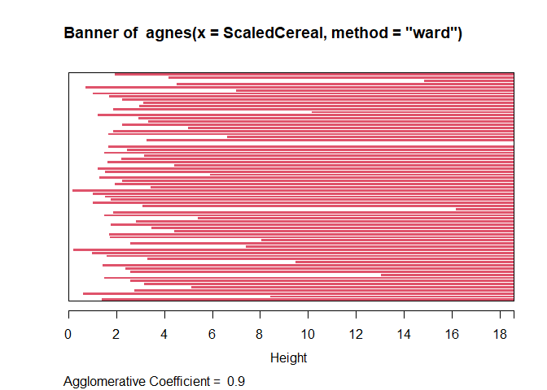

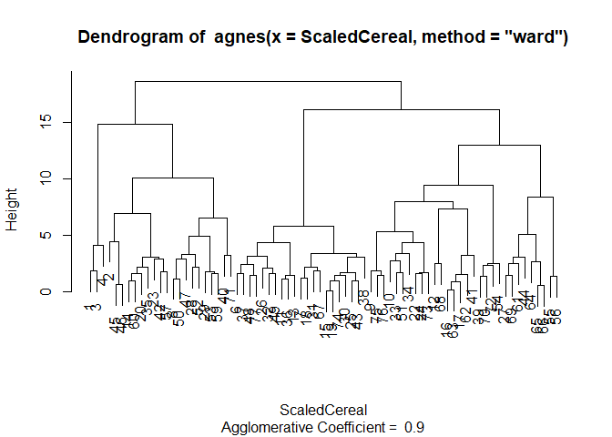

```r
Ward  <- agnes(ScaledCereal, method = "ward")

plot(Ward)
```

```r
Ward$ac # Agglomerative coefficeint is 90 %,stronger cluster structure
```

```
## [1] 0.9046042
```

**From the below Agnes function we see that the Ward method has the strong cluster structure with Agglomerative coefficient of 90% . value close to 1 indicate that structure is stronger.**

```r
data.frame(complete$ac,single$ac,average$ac,Ward$ac)
```

```
##   complete.ac single.ac average.ac   Ward.ac
## 1   0.8353712 0.6067859  0.7766075 0.9046042
```

**● How many clusters would you choose?**

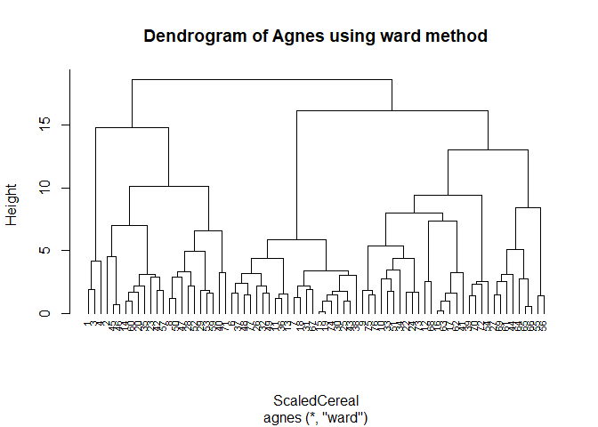

```r
HICereals <- agnes(ScaledCereal,method="ward")

#visualizing the dendogram

pltree(HICereals,cex = 0.7 , hang = -1 , main = "Dendrogram of Agnes using ward method")
```

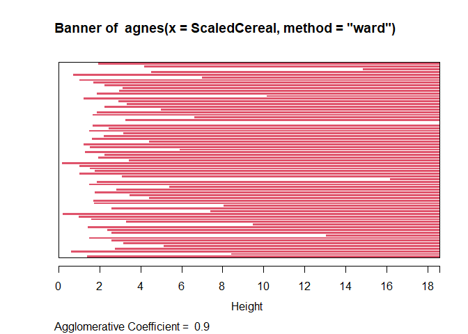

```r
# k value can be determined by looking at the largest difference of height, so K =5 is the optimum.
plot(HICereals)
```

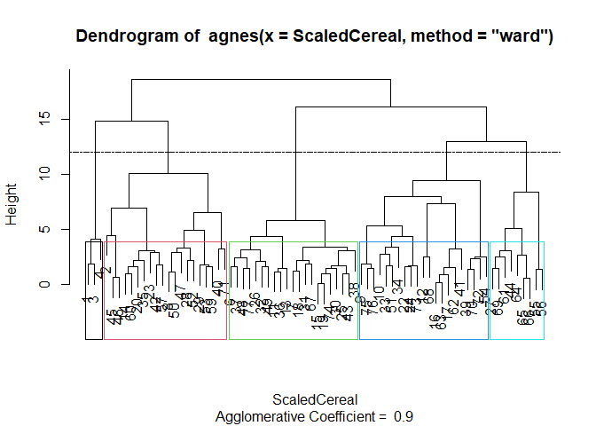

```r
rect.hclust(HICereals, k = 5, border = 1:5,)
abline(h=12,lty=12)
```

```r
#cutting tree
cluster_Tree = cutree(HICereals,k=5)
Cereals_C <- mutate(ScaledCereal,cluster=cluster_Tree)
Cereals_C$cluster # no of cluster
```

```
##  1  2  3  4  6  7  8  9 10 11 12 13 14 15 16 17 18 19 20 22 23 24 25 26 27 28
##  1  2  1  1  3  3  2  4  4  3  4  3  2  3  4  4  3  3  2  4  2  4  3  3  5  2
## 29 30 31 32 33 34 35 36 37 38 39 40 41 42 43 44 45 46 47 48 49 50 51 52 53 54
##  2  3  3  3  4  4  2  3  3  3  4  2  4  2  3  5  2  2  2  3  3  2  4  2  2  4
## 55 56 57 59 60 61 62 63 64 65 66 67 68 69 70 71 72 73 74 75 76 77
##  5  5  2  2  2  5  4  4  5  5  5  3  4  5  4  2  4  4  3  4  4  3
```

**Partitioning the data**

```r
library(caret)
# creating 80% partition of the cluster data
set.seed(1234)
Partition <- createDataPartition(Cereals_C$cluster, p = 0.8 , list = FALSE)

A <- Cereals_C[Partition,]
B <- Cereals_C[-Partition,]

#Finding centroids for A by gathering features and values in partition and grouping is applied by cluster features and then summmarizing the mean values

CentroidA <- A %>% gather("features","values",-cluster) %>% group_by(cluster,features) %>% summarise(mean_values = mean(values)) %>% spread(features,mean_values)

CentroidA # Centroids for each cluseter per column
```

```
## # A tibble: 5 x 14
## # Groups:   cluster [5]
##   cluster calories  carbo   cups    fat   fiber potass protein rating  shelf
##     <int>    <dbl>  <dbl>  <dbl>  <dbl>   <dbl>  <dbl>   <dbl>  <dbl>  <dbl>
## 1       1   -2.87  -1.73  -1.36  -0.993  4.88    3.27   1.38    3.66   0.942
## 2       2    0.738 -0.330 -0.615  0.883  0.386   0.750  0.555  -0.298  0.808
## 3       3    0.239 -0.573  0.208  0     -0.691  -0.772 -0.915  -1.01  -0.543
## 4       4   -0.176  0.825  0.355 -0.409 -0.145  -0.269  0.343   0.312  0.164
## 5       5   -1.30   0.166  0.301 -0.869 -0.0209 -0.147 -0.0126  1.54  -0.410
## # ... with 4 more variables: sodium <dbl>, sugars <dbl>, vitamins <dbl>,
## #   weight <dbl>
```

```r
ClusterB <- data.frame(data=seq(1,nrow(B),1),BClus = rep(0,nrow(B))) # Finding cluster B from the columns and no of row in B and for cluster it is repeated till the last element in last row in B is identified

#Finding minimum distance between centroids in A and each observation in B
#this for loop will essentially calcuate the distance between centroid and Each observation of B till for the complete length of the observation from min vales to the max. x is the element in B

for (x in 1:nrow(B)) {

  ClusterB$BClus[x] <- which.min(as.matrix(get_dist(as.data.frame(rbind(CentroidA[-1],B[x,-length(B)])))) [6,-6])

}

#Comparing B partition with original data , with the original cluster we are comparing what has changed in the new cluster in B.

ClusterB <- ClusterB %>% mutate(originalclust = B$cluster)
mean(ClusterB$BClus == ClusterB$originalclust)
```

```
## [1] 0.9230769
```

based on the above analysis both the original and predicted cluster are 92 % matching. hence cluster have a good stability but some of the distances might be large causing it not to be 100%. This might be due to the data partition.

**The elementary public schools would like to choose a set of cereals to include in their daily cafeterias. Every day a different cereal is offered, but all cereals should support a healthy diet. For this goal, you are requested to find a cluster of “healthy cereals.” Should the data be normalized? If not, how should they be used in the cluster analysis?**

```r
HealthyC <- split(Cereals_C,Cereals_C$cluster) # splitting Cereal cluster from cereal_c data frame
HealthyM <-lapply(HealthyC,colMeans) # Lapply is used to apply a function over a vector/dataframe and returns the same length
(centroids <- do.call(rbind,HealthyM)) # binding data frame which has means to centroids.
```

```
##     calories     protein        fat      sodium       fiber      carbo
## 1 -2.2018711  1.38174776 -0.3310734  0.17279012  3.64131237 -2.0718749
## 2  0.8553248  0.59163927  0.9435592 -0.08898011  0.38141771 -0.2003584
## 3  0.1978117 -0.91996886  0.0000000  0.12101140 -0.66198437 -0.5423583
## 4 -0.1621407  0.18662567 -0.4729620  0.77112209 -0.21003997  0.9626860
## 5 -1.2499969 -0.06420242 -0.8828625 -1.94150793 -0.02664224  0.1551013
##       sugars     potass    vitamins      shelf     weight       cups     rating
## 1 -0.7894824  2.9837813 -0.18184220  0.9419715 -0.2008324 -1.8452553  2.2426479
## 2  0.5143002  0.7475659  0.09849786  0.8217889  0.9235649 -0.5477863 -0.2928786
## 3  0.9583619 -0.7415648 -0.18184220 -0.6604628 -0.2008324  0.2779676 -0.9636465
## 4 -0.8659505 -0.3485391  0.45893508 -0.1453946 -0.2008324  0.4577648  0.2916795
## 5 -1.0953551 -0.1122758 -0.80482011 -0.2598542 -1.0482044  0.1156788  1.4712151
##   cluster
## 1       1
## 2       2
## 3       3
## 4       4
## 5       5
```

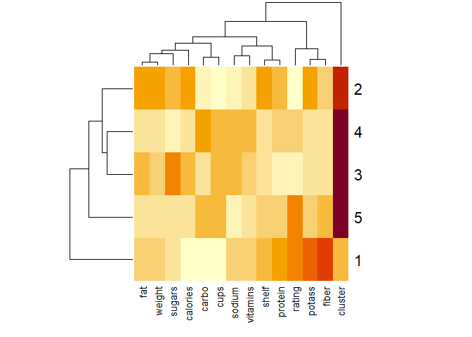

```r
heatmap(centroids) # heatmapof the centroids.s
```

Based on the above analysis, we can observe that the cluster 1(Bran Cereals) is recommended for children as it has high protein ,fiber,potassium and low on calories,sugars and carbs.